# IODS course project

## 4. Standardizing the data set

Before we can easily compare the different variables, we shall scale the values, so they are compatable with one another.

```r
boston_scaled <- scale(Boston)
```

```r
summary(boston_scaled)
```

```
##       crim                 zn               indus
##  Min.   :-0.419367   Min.   :-0.48724   Min.   :-1.5563
##  1st Qu.:-0.410563   1st Qu.:-0.48724   1st Qu.:-0.8668
##  Median :-0.390280   Median :-0.48724   Median :-0.2109
##  Mean   : 0.000000   Mean   : 0.00000   Mean   : 0.0000
##  3rd Qu.: 0.007389   3rd Qu.: 0.04872   3rd Qu.: 1.0150
##  Max.   : 9.924110   Max.   : 3.80047   Max.   : 2.4202
##       chas              nox                rm               age
##  Min.   :-0.2723   Min.   :-1.4644   Min.   :-3.8764   Min.   :-2.3331
##  1st Qu.:-0.2723   1st Qu.:-0.9121   1st Qu.:-0.5681   1st Qu.:-0.8366
##  Median :-0.2723   Median :-0.1441   Median :-0.1084   Median : 0.3171
##  Mean   : 0.0000   Mean   : 0.0000   Mean   : 0.0000   Mean   : 0.0000
##  3rd Qu.:-0.2723   3rd Qu.: 0.5981   3rd Qu.: 0.4823   3rd Qu.: 0.9059
##  Max.   : 3.6648   Max.   : 2.7296   Max.   : 3.5515   Max.   : 1.1164
##       dis               rad               tax             ptratio
##  Min.   :-1.2658   Min.   :-0.9819   Min.   :-1.3127   Min.   :-2.7047
##  1st Qu.:-0.8049   1st Qu.:-0.6373   1st Qu.:-0.7668   1st Qu.:-0.4876
##  Median :-0.2790   Median :-0.5225   Median :-0.4642   Median : 0.2746
##  Mean   : 0.0000   Mean   : 0.0000   Mean   : 0.0000   Mean   : 0.0000
##  3rd Qu.: 0.6617   3rd Qu.: 1.6596   3rd Qu.: 1.5294   3rd Qu.: 0.8058
##  Max.   : 3.9566   Max.   : 1.6596   Max.   : 1.7964   Max.   : 1.6372
##      black             lstat              medv
##  Min.   :-3.9033   Min.   :-1.5296   Min.   :-1.9063
##  1st Qu.: 0.2049   1st Qu.:-0.7986   1st Qu.:-0.5989
##  Median : 0.3808   Median :-0.1811   Median :-0.1449
##  Mean   : 0.0000   Mean   : 0.0000   Mean   : 0.0000
##  3rd Qu.: 0.4332   3rd Qu.: 0.6024   3rd Qu.: 0.2683
##  Max.   : 0.4406   Max.   : 3.5453   Max.   : 2.9865
```

[output not shown]

From this new scaled variable we can see that all the variable values range between -10 and 10. This will probably lead to an easier way to compare the different variables.

Now I shall create a chategorical variable of the crime rates in Boston. I will do this, because it is not possible to use the numerical values in some of the codes that we have to make so we get the wanted results.

```r
scaled_crim <-boston_scaled$crim
```

Now I need to use the quantiles as break points in the variable. The quantiles are 0%, 25%, 50%, 75% and 100%. This makes it easier to understand how the values are distributed in a specific variable. The variable that I am using is the ‘crim’ variable.

```
##           0%          25%          50%          75%         100%
## -0.419366929 -0.410563278 -0.390280295  0.007389247  9.924109610
```

As we can see, I have created breaking points at the quantlies. So from these we can interpet that half of the variable values are between values -0,419 and -0,390. So we can conclude that there isn’t a very big difference between the first 50% of the data. The big difference is found between the last 25% (75%-100%), where the values are distributed between 0,00738 and 9,9241. I would interpet this as there being a few towns with extremely high crime rates in comparison to other towns.

Next I will create a new variable ‘crime’ that consists of the scaled crim values, its breaks consists of the quartiles, and we are labeling 4 different groupings on the rates of crimes. The groupings are low-, medium low-, medium high- and very high crime rates.

```r
crime <- cut(scaled_crim, breaks = bins, include.lowest = TRUE, labels = c("low", "med_low", "med_high", "high"))
```

```r
table(crime)
```

```
## crime
##      low  med_low med_high     high
##      127      126      126      127
```

Next I will have to drop the old crime rate (‘crim’) variable from the data set. This I will do, because the new crime rate is more sufficient to my needs of analysis.

```r
boston_scaled <- dplyr::select(boston_scaled, -crim)
```

```r
boston_scaled <- data.frame(boston_scaled, crime)
```

Next I shall divide the scaled_boston data into two different data sets; ‘test’ and ‘train’. But before I can divide the data to two new data sets, I need to figure out how many rows the boston_scaled variable has. The number of rows is saved as he variable ‘n’.

```r
n <-nrow(boston_scaled)
```

Next I need to take a sample of the data, and in the task 80% ov the data will go to the ‘train’ data set, so we need a sample that cover 80% of the scaled_boston data set. This variable shall be named ind.

```r
ind <- sample(n,  size = n * 0.8)
```

Now we can divide the scaled_data set into the two new data sets ‘train’ and ‘test’

```r
train <- boston_scaled[ind,]
```

```r
test <- boston_scaled[-ind,]
```

## 5. Linear discriminant analysis: train set

In the linear discriminant analysis I will be looking at the target variable crime, and all the other values are predictors of the crime value. We can also see the predictor variables being grouped by the labels low, med_low, med_high and high. At the bottom we can also find the coefficients of the linear discriminants.

```r
lda.fit
```

```
## Call:
## lda(crime ~ ., data = train)
##
## Prior probabilities of groups:
##       low   med_low  med_high      high
## 0.2450495 0.2500000 0.2549505 0.2500000
##
## Group means:
##                  zn      indus        chas        nox         rm
## low       0.9188267 -0.9427484 -0.19279169 -0.8904122  0.4882351
## med_low  -0.1306383 -0.2570440 -0.07742312 -0.5282372 -0.1688605
## med_high -0.4031510  0.1789540  0.10991367  0.3715341  0.1647330
## high     -0.4872402  1.0149946 -0.03844192  1.0257316 -0.4004416
##                 age        dis        rad        tax     ptratio
## low      -0.8799951  0.8696487 -0.6906942 -0.7282200 -0.52908148
## med_low  -0.2707195  0.3120774 -0.5475005 -0.4706753 -0.06269516
## med_high  0.3955687 -0.3799710 -0.4098677 -0.3079283 -0.21355259
## high      0.7863199 -0.8499182  1.6596029  1.5294129  0.80577843
##                black        lstat       medv
## low       0.37501760 -0.774201257  0.5645740
## med_low   0.31915547 -0.074037565 -0.0380161
## med_high  0.09820465 -0.007580274  0.1955248
## high     -0.71664070  0.880503386 -0.6654198
##
## Coefficients of linear discriminants:
##                   LD1         LD2         LD3
## zn       1.308273e-01  0.66675102 -0.83686317
## indus    2.631685e-03 -0.30982775  0.41178991
## chas    -6.879513e-02 -0.03881127  0.14356667
## nox      3.200918e-01 -0.81442845 -1.43694903
## rm      -1.188405e-01 -0.10165099 -0.23157754
## age      2.873173e-01 -0.28425479 -0.01836423
## dis     -9.772964e-02 -0.24104751  0.14685506
## rad      3.427485e+00  0.86085236  0.04686783
## tax     -5.061425e-05  0.13912071  0.32874987
## ptratio  1.934539e-01 -0.07205613 -0.28832367
## black   -1.509661e-01  0.01340489  0.12627475
## lstat    1.651408e-01 -0.20394514  0.34579882
## medv     1.781535e-01 -0.37459575 -0.23600187
##
## Proportion of trace:
##    LD1    LD2    LD3
## 0.9543 0.0344 0.0113
```

Next we want to visualize the distribution of these different variables are distributed. The different labeling chategorize are coded in different colors. The low value is black, med_low is red, med_high is green and the high values are blue. The different variables are also coded in ted, and they also have arrows that point in what direction they move.

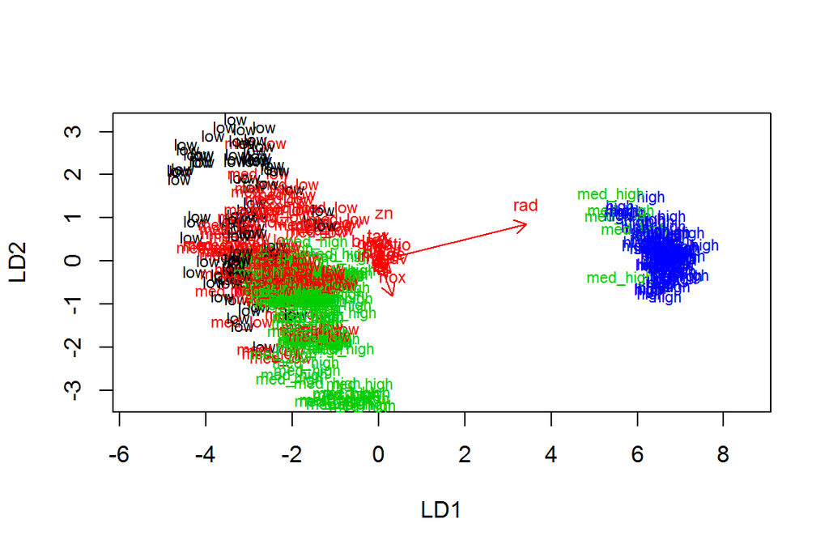

## 6. Predicting the classes

Next task is to predict classes. This I will do with the test data frame. The prediction is made to evaluate what kind of values a specific variable is supposed to give, based upon some values.

```r
table(correct = correct_classes, predicted = lda.pred$class)
```

```
##           predicted
## correct    low med_low med_high high
##   low       19       7        2    0
##   med_low    7      17        1    0
##   med_high   1       6       15    1
##   high       0       0        1   25
```

Here we can compare between the actual values and the predicted values and how much they differ from each other.

## 7. Reloading the Boston data set

Reloading and scaling the Boston data set

```r
summary(dist_eu)
```

```
##    Min. 1st Qu.  Median    Mean 3rd Qu.    Max.
##  0.1343  3.4620  4.8240  4.9110  6.1860 14.4000
```

Here we have the distances between the calcultations in the scaled Boston data frame.

Next I will be running k-means on the scaled Boston variable. And I will also visualize the distribution of the different variables.

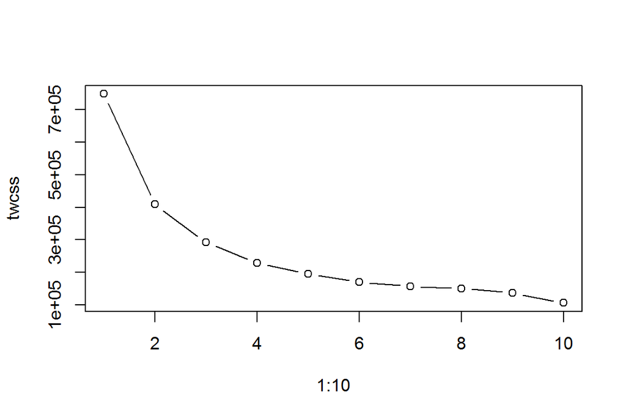

From this image I shall conclude what the best number of centers I will use in the visualizing stage of the material. So I will choose the number 3, because this image tilts a little at the number 3.

### Visualizing the distribution

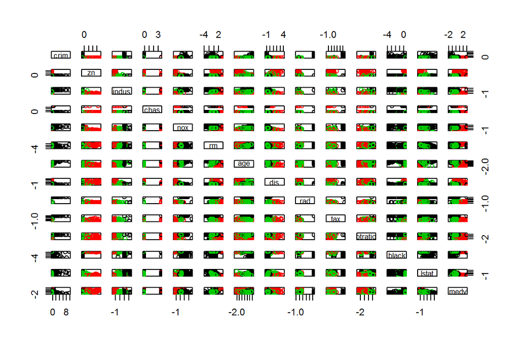

Now we hade the 3 centers displayed in 3 different colors. We can observe that ‘medv’ variable compared with all the other variables is always green on the right hand side, red in the left side, and black on the top left side. We can also see some variables that are coded with either 0 or 1 that they are colors only on the very right and very left of the box (i.e. chas, rad). On the ‘zn’ variable there is almost only the colors green and red. The ‘crim’ variable is mostly colored black with only a little of green and red with some variables.

# Chapter 5: Dimensionality reduction techniques

## 1. Load data, briefly explore the data

To explore this data frame, I shall execute the codes that will bring the structure of the human data file and its dimensions.

```r
human <-read.table("http://s3.amazonaws.com/assets.datacamp.com/production/course_2218/datasets/human2.txt", sep = ",", header = TRUE)
```

```r
str(human)
```

```
## 'data.frame':    155 obs. of  8 variables:
##  $ Edu2.FM  : num  1.007 0.997 0.983 0.989 0.969 ...
##  $ Labo.FM  : num  0.891 0.819 0.825 0.884 0.829 ...
##  $ Edu.Exp  : num  17.5 20.2 15.8 18.7 17.9 16.5 18.6 16.5 15.9 19.2 ...
##  $ Life.Exp : num  81.6 82.4 83 80.2 81.6 80.9 80.9 79.1 82 81.8 ...
##  $ GNI      : int  64992 42261 56431 44025 45435 43919 39568 52947 42155 32689 ...
##  $ Mat.Mor  : int  4 6 6 5 6 7 9 28 11 8 ...
##  $ Ado.Birth: num  7.8 12.1 1.9 5.1 6.2 3.8 8.2 31 14.5 25.3 ...
##  $ Parli.F  : num  39.6 30.5 28.5 38 36.9 36.9 19.9 19.4 28.2 31.4 ...
```

```r
dim(human)
```

```
## [1] 155   8
```

As we can see, the data consists of 8 variables and 155 observations. The variables as Edu2.FM that consists of the male and female proportion with at least secondary education. LaboFM is the proportion of male and female within the labour force. Edu.Exp consists of the expected years of schooling. The Life.Exp is the life expectency at birth. GNI variable counts the Gross National Income per capita. Mat.Mor counts the maternal mortality ratio. Ado.Birth is the rate of adolescent births. And the last variable is Parli.F that measures the percentages of female representatives in the parliament.

## 2. Graphical overview

Here I present the human data file where every variable is compared with each other variable, and creates a matrix.

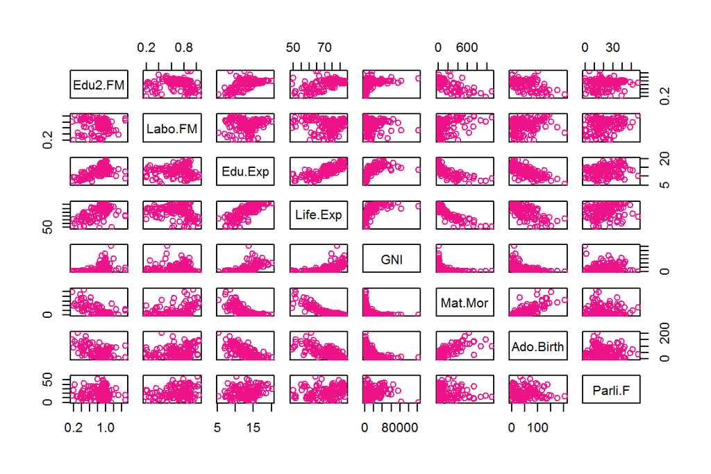

```r
pairs(human, col = "deeppink2")
```

From this image we can assume i.e. the longer expected education time the lower is the maternal mortality. Also the longer expected education time the higher is the life expectancy. Some variables like the percentages of women in the parliament does not give any clear results compared to other variables. Something very interesting is that the maternal mortality increaces when it is compared to the Labour force variable.

```r
summary(human)
```

```
##     Edu2.FM          Labo.FM          Edu.Exp         Life.Exp
##  Min.   :0.1717   Min.   :0.1857   Min.   : 5.40   Min.   :49.00
##  1st Qu.:0.7264   1st Qu.:0.5984   1st Qu.:11.25   1st Qu.:66.30
##  Median :0.9375   Median :0.7535   Median :13.50   Median :74.20
##  Mean   :0.8529   Mean   :0.7074   Mean   :13.18   Mean   :71.65
##  3rd Qu.:0.9968   3rd Qu.:0.8535   3rd Qu.:15.20   3rd Qu.:77.25
##  Max.   :1.4967   Max.   :1.0380   Max.   :20.20   Max.   :83.50
##       GNI            Mat.Mor         Ado.Birth         Parli.F
##  Min.   :   581   Min.   :   1.0   Min.   :  0.60   Min.   : 0.00
##  1st Qu.:  4198   1st Qu.:  11.5   1st Qu.: 12.65   1st Qu.:12.40
##  Median : 12040   Median :  49.0   Median : 33.60   Median :19.30
##  Mean   : 17628   Mean   : 149.1   Mean   : 47.16   Mean   :20.91
##  3rd Qu.: 24512   3rd Qu.: 190.0   3rd Qu.: 71.95   3rd Qu.:27.95
##  Max.   :123124   Max.   :1100.0   Max.   :204.80   Max.   :57.50
```

From this summary we can see that some of the variables has a very widley spred distribution. This we can see in the maternal mortality variable, where the minimun value is 1, and the maximum value is 1100. Though it is more fruitfull to compare the first and thirs quartiles, to get a better understanding of where most of the observations are located. Another variable that caught my attenttion is the percenteges of women in parliament, that ranges from 0% to 57,5%. This is quite interesting, because here we assume there to be women in the parliament, whereas in other countries this is obviously not the case.

## 3. Principal Component Analysis (unstandardized data)

Here I tried to do a biplot of the unstandardized human data file, but as you can see, it has not worked out as it should have.

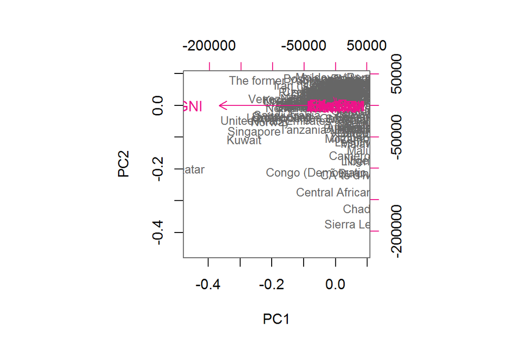

```r
biplot(pca_human, choices = 1:2, cex = c(0.8, 1), col = c("grey40", "deeppink2"))
```

## 4. Principal Component Analysis (standardized data)

```r
summary(human_std)
```

```
##     Edu2.FM           Labo.FM           Edu.Exp           Life.Exp
##  Min.   :-2.8189   Min.   :-2.6247   Min.   :-2.7378   Min.   :-2.7188
##  1st Qu.:-0.5233   1st Qu.:-0.5484   1st Qu.:-0.6782   1st Qu.:-0.6425
##  Median : 0.3503   Median : 0.2316   Median : 0.1140   Median : 0.3056
##  Mean   : 0.0000   Mean   : 0.0000   Mean   : 0.0000   Mean   : 0.0000
##  3rd Qu.: 0.5958   3rd Qu.: 0.7350   3rd Qu.: 0.7126   3rd Qu.: 0.6717
##  Max.   : 2.6646   Max.   : 1.6632   Max.   : 2.4730   Max.   : 1.4218
##       GNI             Mat.Mor          Ado.Birth          Parli.F
##  Min.   :-0.9193   Min.   :-0.6992   Min.   :-1.1325   Min.   :-1.8203
##  1st Qu.:-0.7243   1st Qu.:-0.6496   1st Qu.:-0.8394   1st Qu.:-0.7409
##  Median :-0.3013   Median :-0.4726   Median :-0.3298   Median :-0.1403
##  Mean   : 0.0000   Mean   : 0.0000   Mean   : 0.0000   Mean   : 0.0000
##  3rd Qu.: 0.3712   3rd Qu.: 0.1932   3rd Qu.: 0.6030   3rd Qu.: 0.6127
##  Max.   : 5.6890   Max.   : 4.4899   Max.   : 3.8344   Max.   : 3.1850
```

Here we have the human data file that has been scaled, so that we can use it to run a principal component analysis.

Underneith we have the different principal components lined up. There are all together 8 different principal components. The first principal component has the highest amount of variance compared to the other principal components. The second principal component captures the next highest amount of variances and so forth.

We can observe that the first principal component captures 53.6% of the variances, and the secound principal component captures 16.2% and so on.

```r
s <-summary(pca_human_std)
s
```

```
## Importance of components:
##                           PC1    PC2     PC3     PC4     PC5     PC6
## Standard deviation     2.0708 1.1397 0.87505 0.77886 0.66196 0.53631
## Proportion of Variance 0.5361 0.1624 0.09571 0.07583 0.05477 0.03595
## Cumulative Proportion  0.5361 0.6984 0.79413 0.86996 0.92473 0.96069
##                            PC7     PC8
## Standard deviation     0.45900 0.32224
## Proportion of Variance 0.02634 0.01298
## Cumulative Proportion  0.98702 1.00000
```

```r
pca_pr <- round(100*s$importance[2,], digits = 1)
pca_pr
```

```
##  PC1  PC2  PC3  PC4  PC5  PC6  PC7  PC8
## 53.6 16.2  9.6  7.6  5.5  3.6  2.6  1.3
```

Here underneath I made a biplot of the standardized human data that has undergone a principal component analysis. In the table you can see all the countries written in grey color and all the variables in pink colors with similar arrows.

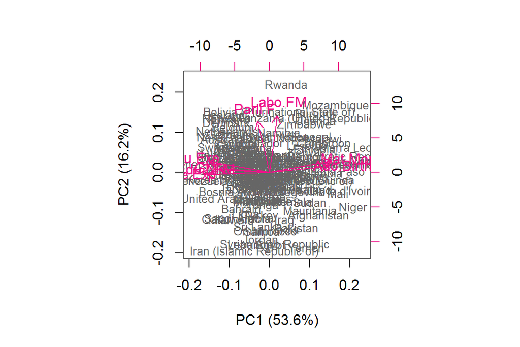

```r
pc_lab <- paste0(names(pca_pr), " (", pca_pr, "%)")
biplot(pca_human_std, cex = c(0.8, 1), col = c("grey40", "deeppink2"), xlab = pc_lab[1], ylab = pc_lab[2])
```

## 5. Personal interpretations

The differences between the two principal component analysis where one is standarsized and the other unstandardized, is the possibility to extract information. In the unstandardized principal component analysis the values of the different variables vary very much. For example the GNI variable gets much higher values than all the other values, and this leads to it being impossible to interpet the variable correlation.

To interpet this biplot, I understood that a small arrow angle means a high positive correlation. And also that the arrows length is somehow proportional to the standard deviations.

From the biplot, I can interpet that the Ado.Birth and Mat.Mor variables as a high correlation, do to their closeness of the arrows and the similar angle. The same can be said of the 4 variables GNI, Edu.Exp., Life.Exp and Edu2.FM, that they have a very strong positive corrleation between each other because all the arrows are in a similar angle and very close to each other. The last to variables in the standardized human data set are the Parli.F and Labo.FM variabled that as some kind of positive correlation between each other too.

## 6. Factominer, Multiple Correspondence Analysis

Here the task is to explore and visualize the data frame called tea. The data frame tea consists of 36 variables and 300 observations. The data is literally information on what kind of tea habits people have. The next task is to just keep some of the columns.

```r
library(FactoMineR)
library(ggplot2)
library(tidyr)
library(corrplot)
library(MASS)
library(dplyr)
data("tea")
```

```r
str(tea)
```

```
## 'data.frame':    300 obs. of  36 variables:
##  $ breakfast       : Factor w/ 2 levels "breakfast","Not.breakfast": 1 1 2 2 1 2 1 2 1 1 ...
##  $ tea.time        : Factor w/ 2 levels "Not.tea time",..: 1 1 2 1 1 1 2 2 2 1 ...
##  $ evening         : Factor w/ 2 levels "evening","Not.evening": 2 2 1 2 1 2 2 1 2 1 ...
##  $ lunch           : Factor w/ 2 levels "lunch","Not.lunch": 2 2 2 2 2 2 2 2 2 2 ...
##  $ dinner          : Factor w/ 2 levels "dinner","Not.dinner": 2 2 1 1 2 1 2 2 2 2 ...
##  $ always          : Factor w/ 2 levels "always","Not.always": 2 2 2 2 1 2 2 2 2 2 ...
##  $ home            : Factor w/ 2 levels "home","Not.home": 1 1 1 1 1 1 1 1 1 1 ...
##  $ work            : Factor w/ 2 levels "Not.work","work": 1 1 2 1 1 1 1 1 1 1 ...
##  $ tearoom         : Factor w/ 2 levels "Not.tearoom",..: 1 1 1 1 1 1 1 1 1 2 ...
##  $ friends         : Factor w/ 2 levels "friends","Not.friends": 2 2 1 2 2 2 1 2 2 2 ...
##  $ resto           : Factor w/ 2 levels "Not.resto","resto": 1 1 2 1 1 1 1 1 1 1 ...
##  $ pub             : Factor w/ 2 levels "Not.pub","pub": 1 1 1 1 1 1 1 1 1 1 ...
##  $ Tea             : Factor w/ 3 levels "black","Earl Grey",..: 1 1 2 2 2 2 2 1 2 1 ...
##  $ How             : Factor w/ 4 levels "alone","lemon",..: 1 3 1 1 1 1 1 3 3 1 ...
```

[output cut: 22 more lines]

```r
dim(tea)
```

```
## [1] 300  36
```

Here I will summarise the new variable tea_time, that consists of different chategorize: Tea, How, how, sugar, where and lunch. These chategorize have different variables. For example the tea chategory consists of 3 alternative variables: black, Earl Grey and green. So this Tea variable wants so present what kinds of tea is consumed.

```r
summary(tea_time)
```

```
##         Tea         How                      how           sugar
##  black    : 74   alone:195   tea bag           :170   No.sugar:155
##  Earl Grey:193   lemon: 33   tea bag+unpackaged: 94   sugar   :145
##  green    : 33   milk : 63   unpackaged        : 36
##                  other:  9
##                   where           lunch
##  chain store         :192   lunch    : 44
##  chain store+tea shop: 78   Not.lunch:256
##  tea shop            : 30
##
```

Here is the distribution of the different variables.

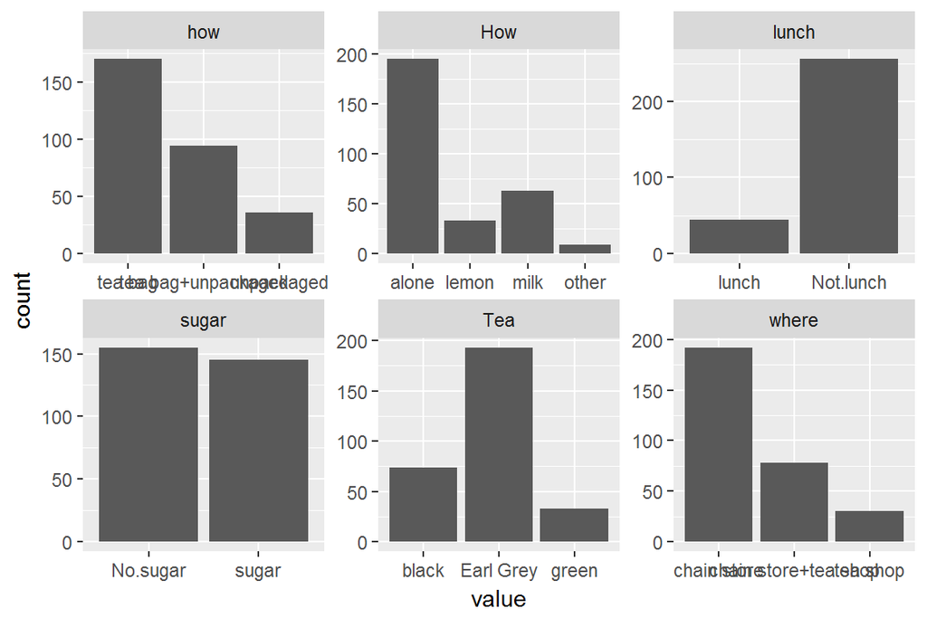

```r
gather(tea_time) %>% ggplot(aes(value)) + facet_wrap("key", scales = "free") + geom_bar()
```

Next I shall run a multiple correspondence analysis on the tea_time variable. We can see in the Eigenvalues that there is a total of 11 dimensions that explain all the variances in the tea_time data. The first dimension has the largest variances and so forth.

In the Individuals, were we are looking at the 10 first individuals, that the first value represents the coordinates, their contribution of the dimension in percent and the squared corrleation of the dimension. The Categories variable measures the same 3 things as just mensioned, but it also measures the variables v:test value. The Categorical Variables (eta2) value measures the squared correlation between each variable and dimension. If the value of the Categorical Values are close to one, there is a strong link with the variable and dimension. I.e. ‘how’ variable has a strong link with the first dimension (0,708).

```r
summary(mca)
```

```
##
## Call:
## MCA(X = tea_time, graph = FALSE)
##
##
## Eigenvalues
##                        Dim.1   Dim.2   Dim.3   Dim.4   Dim.5   Dim.6
## Variance               0.279   0.261   0.219   0.189   0.177   0.156
## % of var.             15.238  14.232  11.964  10.333   9.667   8.519
## Cumulative % of var.  15.238  29.471  41.435  51.768  61.434  69.953
##                        Dim.7   Dim.8   Dim.9  Dim.10  Dim.11
## Variance               0.144   0.141   0.117   0.087   0.062
## % of var.              7.841   7.705   6.392   4.724   3.385
## Cumulative % of var.  77.794  85.500  91.891  96.615 100.000
##
## Individuals (the 10 first)
##                       Dim.1    ctr   cos2    Dim.2    ctr   cos2    Dim.3
## 1                  | -0.298  0.106  0.086 | -0.328  0.137  0.105 | -0.327
## 2                  | -0.237  0.067  0.036 | -0.136  0.024  0.012 | -0.695
## 3                  | -0.369  0.162  0.231 | -0.300  0.115  0.153 | -0.202
## 4                  | -0.530  0.335  0.460 | -0.318  0.129  0.166 |  0.211
## 5                  | -0.369  0.162  0.231 | -0.300  0.115  0.153 | -0.202
## 6                  | -0.369  0.162  0.231 | -0.300  0.115  0.153 | -0.202
## 7                  | -0.369  0.162  0.231 | -0.300  0.115  0.153 | -0.202
## 8                  | -0.237  0.067  0.036 | -0.136  0.024  0.012 | -0.695
## 9                  |  0.143  0.024  0.012 |  0.871  0.969  0.435 | -0.067
## 10                 |  0.476  0.271  0.140 |  0.687  0.604  0.291 | -0.650
##                       ctr   cos2
## 1                   0.163  0.104 |
## 2                   0.735  0.314 |
## 3                   0.062  0.069 |
## 4                   0.068  0.073 |
## 5                   0.062  0.069 |
## 6                   0.062  0.069 |
## 7                   0.062  0.069 |
## 8                   0.735  0.314 |
## 9                   0.007  0.003 |
## 10                  0.643  0.261 |
##
## Categories (the 10 first)
```

[output cut: 16 more lines]

```
## lemon                0.035   3.226 |   1.329  14.771   0.218   8.081 |
## milk                 0.020   2.422 |   0.013   0.003   0.000   0.116 |
## other                0.102   5.534 |  -2.524  14.526   0.197  -7.676 |
## tea bag              0.161  -6.941 |  -0.065   0.183   0.006  -1.287 |
## tea bag+unpackaged   0.478  11.956 |   0.019   0.009   0.000   0.226 |
## unpackaged           0.141  -6.482 |   0.257   0.602   0.009   1.640 |
##
## Categorical variables (eta2)
##                      Dim.1 Dim.2 Dim.3
## Tea                | 0.126 0.108 0.410 |
## How                | 0.076 0.190 0.394 |
## how                | 0.708 0.522 0.010 |
## sugar              | 0.065 0.001 0.336 |
## where              | 0.702 0.681 0.055 |
## lunch              | 0.000 0.064 0.111 |
```

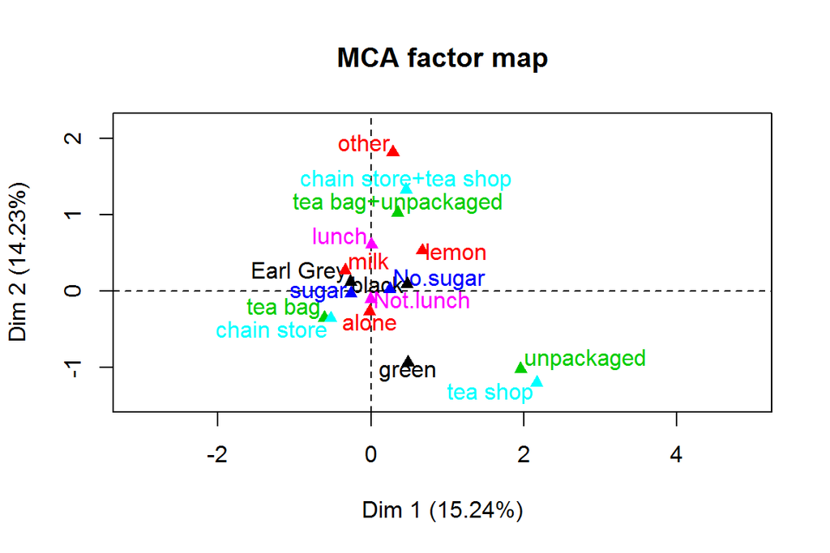

```r
plot(mca, invisible=c("ind"), habillage = "quali")
```

From this output I am slihtly unsurtain how to interpet this table. The colors represent the different categorical groups they belong in. It is very interesting that the ‘how’ variable has a strong corrleation with the first dimension (green) but all the different variables are very scattered in the table. Does a strong correlation with the dimension mean aa widley spread table?